# EasyVisa Project

## Context:

Business communities in the United States are facing high demand for human resources, but one of the constant challenges is identifying and attracting the right talent, which is perhaps the most important element in remaining competitive. Companies in the United States look for hard-working, talented, and qualified individuals both locally as well as abroad.

The Immigration and Nationality Act (INA) of the US permits foreign workers to come to the United States to work on either a temporary or permanent basis. The act also protects US workers against adverse impacts on their wages or working conditions by ensuring US employers' compliance with statutory requirements when they hire foreign workers to fill workforce shortages. The immigration programs are administered by the Office of Foreign Labor Certification (OFLC).

OFLC processes job certification applications for employers seeking to bring foreign workers into the United States and grants certifications in those cases where employers can demonstrate that there are not sufficient US workers available to perform the work at wages that meet or exceed the wage paid for the occupation in the area of intended employment.

## Objective:

In FY 2016, the OFLC processed 775,979 employer applications for 1,699,957 positions for temporary and permanent labor certifications. This was a nine percent increase in the overall number of processed applications from the previous year. The process of reviewing every case is becoming a tedious task as the number of applicants is increasing every year.

The increasing number of applicants every year calls for a Machine Learning based solution that can help in shortlisting the candidates having higher chances of VISA approval. OFLC has hired your firm EasyVisa for data-driven solutions. You as a data scientist have to analyze the data provided and, with the help of a classification model:

- Facilitate the process of visa approvals.
- Recommend a suitable profile for the applicants for whom the visa should be certified or denied based on the drivers that significantly influence the case status.

## Data Description

The data contains the different attributes of the employee and the employer. The detailed data dictionary is given below.

- case_id: ID of each visa application
- continent: Information of continent the employee
- education_of_employee: Information of education of the employee
- has_job_experience: Does the employee has any job experience? Y= Yes; N = No
- requires_job_training: Does the employee require any job training? Y = Yes; N = No
- no_of_employees: Number of employees in the employer's company
- yr_of_estab: Year in which the employer's company was established
- region_of_employment: Information of foreign worker's intended region of employment in the US.
- prevailing_wage: Average wage paid to similarly employed workers in a specific occupation in the area of intended employment. The purpose of the prevailing wage is to ensure that the foreign worker is not underpaid compared to other workers offering the same or similar service in the same area of employment.
- unit_of_wage: Unit of prevailing wage. Values include Hourly, Weekly, Monthly, and Yearly.
- full_time_position: Is the position of work full-time? Y = Full Time Position; N = Part Time Position
- case_status: Flag indicating if the Visa was certified or denied

## Importing necessary libraries and data

```python
# filter warnings
import warnings
warnings.filterwarnings("ignore")

# data import, cleaning, and manipulation
import numpy as np
import pandas as pd

# set pandas limits for tables
pd.set_option("display.max_columns", None)
# Sets the limit for the number of displayed rows
pd.set_option("display.max_rows", 100)

# data visualization
import matplotlib.pyplot as plt
import seaborn as sns

# from scikit-learn library
# split data
from sklearn.model_selection import train_test_split

# ensemble classifiers
from sklearn.ensemble import (
    BaggingClassifier,
    RandomForestClassifier,
    AdaBoostClassifier,
    GradientBoostingClassifier,
    StackingClassifier,
)
from sklearn.tree import DecisionTreeClassifier

# metric scores
from sklearn import metrics
from sklearn.metrics import (
    confusion_matrix,
    accuracy_score,
    precision_score,
    recall_score,
    f1_score,
)

# model tuning
from sklearn.model_selection import GridSearchCV

# XGBoost
from xgboost import XGBClassifier
```

```python
# import data
df = pd.read_csv('EasyVisa.csv')
df_copy = df.copy()
```

## Data Overview

- Observations
- Sanity checks

### Preview Data

```python
df.head()
```

|  | case_id | continent | education_of_employee | has_job_experience | requires_job_training | no_of_employees | yr_of_estab | region_of_employment | prevailing_wage | unit_of_wage | full_time_position | case_status |
| --- | --- | --- | --- | --- | --- | --- | --- | --- | --- | --- | --- | --- |
| 0 | EZYV01 | Asia | High School | N | N | 14513 | 2007 | West | 592.2029 | Hour | Y | Denied |
| 1 | EZYV02 | Asia | Master's | Y | N | 2412 | 2002 | Northeast | 83425.6500 | Year | Y | Certified |
| 2 | EZYV03 | Asia | Bachelor's | N | Y | 44444 | 2008 | West | 122996.8600 | Year | Y | Denied |
| 3 | EZYV04 | Asia | Bachelor's | N | N | 98 | 1897 | West | 83434.0300 | Year | Y | Denied |
| 4 | EZYV05 | Africa | Master's | Y | N | 1082 | 2005 | South | 149907.3900 | Year | Y | Certified |

```python
df.tail()
```

|  | case_id | continent | education_of_employee | has_job_experience | requires_job_training | no_of_employees | yr_of_estab | region_of_employment | prevailing_wage | unit_of_wage | full_time_position | case_status |
| --- | --- | --- | --- | --- | --- | --- | --- | --- | --- | --- | --- | --- |
| 25475 | EZYV25476 | Asia | Bachelor's | Y | Y | 2601 | 2008 | South | 77092.57 | Year | Y | Certified |
| 25476 | EZYV25477 | Asia | High School | Y | N | 3274 | 2006 | Northeast | 279174.79 | Year | Y | Certified |
| 25477 | EZYV25478 | Asia | Master's | Y | N | 1121 | 1910 | South | 146298.85 | Year | N | Certified |
| 25478 | EZYV25479 | Asia | Master's | Y | Y | 1918 | 1887 | West | 86154.77 | Year | Y | Certified |
| 25479 | EZYV25480 | Asia | Bachelor's | Y | N | 3195 | 1960 | Midwest | 70876.91 | Year | Y | Certified |

```python
df.info()
```

```
<class 'pandas.core.frame.DataFrame'>
RangeIndex: 25480 entries, 0 to 25479
Data columns (total 12 columns):
 #   Column                 Non-Null Count  Dtype
---  ------                 --------------  -----
 0   case_id                25480 non-null  object
 1   continent              25480 non-null  object
 2   education_of_employee  25480 non-null  object
 3   has_job_experience     25480 non-null  object
 4   requires_job_training  25480 non-null  object
 5   no_of_employees        25480 non-null  int64
 6   yr_of_estab            25480 non-null  int64
 7   region_of_employment   25480 non-null  object
 8   prevailing_wage        25480 non-null  float64
 9   unit_of_wage           25480 non-null  object
 10  full_time_position     25480 non-null  object
 11  case_status            25480 non-null  object
dtypes: float64(1), int64(2), object(9)
memory usage: 2.3+ MB
```

**Check for duplicates and missing data**

```python
# check for duplicate rows
df.duplicated().sum()
```

```
0
```

```python
# check for missing data
df.isnull().sum()
```

```
case_id                  0
continent                0
education_of_employee    0
has_job_experience       0
requires_job_training    0
no_of_employees          0
yr_of_estab              0
region_of_employment     0
prevailing_wage          0
unit_of_wage             0
full_time_position       0
case_status              0
dtype: int64
```

### Data Summary

```python
# statistical summary
df.select_dtypes(include='number').describe()
```

|  | no_of_employees | yr_of_estab | prevailing_wage |
| --- | --- | --- | --- |
| count | 25480.000000 | 25480.000000 | 25480.000000 |
| mean | 5667.043210 | 1979.409929 | 74455.814592 |
| std | 22877.928848 | 42.366929 | 52815.942327 |
| min | -26.000000 | 1800.000000 | 2.136700 |
| 25% | 1022.000000 | 1976.000000 | 34015.480000 |
| 50% | 2109.000000 | 1997.000000 | 70308.210000 |
| 75% | 3504.000000 | 2005.000000 | 107735.512500 |
| max | 602069.000000 | 2016.000000 | 319210.270000 |

- The min for no_of_employees is -26 but there shouldn't be any negative values in this column.

**Check no_of_employees for negative values and convert them to positive values**

```python
# check for negative no_of_employees
df['no_of_employees'][df['no_of_employees']<0]
```

```
245     -25
378     -11
832     -17
2918    -26
6439    -14
6634    -26
7224    -25
7281    -14
7318    -26
7761    -11
9872    -26
11493   -14
13471   -17
14022   -11
14146   -26
```

[output cut: 19 more lines]

```python
# replace all negative values in no_of_employees with positive values
df['no_of_employees'] = df['no_of_employees'].abs()
```

```python
df.select_dtypes(include='number').describe()
```

|  | no_of_employees | yr_of_estab | prevailing_wage |
| --- | --- | --- | --- |
| count | 25480.000000 | 25480.000000 | 25480.000000 |
| mean | 5667.089207 | 1979.409929 | 74455.814592 |
| std | 22877.917453 | 42.366929 | 52815.942327 |
| min | 11.000000 | 1800.000000 | 2.136700 |
| 25% | 1022.000000 | 1976.000000 | 34015.480000 |
| 50% | 2109.000000 | 1997.000000 | 70308.210000 |
| 75% | 3504.000000 | 2005.000000 | 107735.512500 |
| max | 602069.000000 | 2016.000000 | 319210.270000 |

**Drop columns that are not needed**

```python
# drop case_id col
df.drop('case_id', axis=1, inplace=True)
```

```python
df.head()
```

|  | continent | education_of_employee | has_job_experience | requires_job_training | no_of_employees | yr_of_estab | region_of_employment | prevailing_wage | unit_of_wage | full_time_position | case_status |
| --- | --- | --- | --- | --- | --- | --- | --- | --- | --- | --- | --- |
| 0 | Asia | High School | N | N | 14513 | 2007 | West | 592.2029 | Hour | Y | Denied |
| 1 | Asia | Master's | Y | N | 2412 | 2002 | Northeast | 83425.6500 | Year | Y | Certified |
| 2 | Asia | Bachelor's | N | Y | 44444 | 2008 | West | 122996.8600 | Year | Y | Denied |
| 3 | Asia | Bachelor's | N | N | 98 | 1897 | West | 83434.0300 | Year | Y | Denied |
| 4 | Africa | Master's | Y | N | 1082 | 2005 | South | 149907.3900 | Year | Y | Certified |

## Exploratory Data Analysis (EDA)

- EDA is an important part of any project involving data.
- It is important to investigate and understand the data better before building a model with it.
- A few questions have been mentioned below which will help you approach the analysis in the right manner and generate insights from the data.
- A thorough analysis of the data, in addition to the questions mentioned below, should be done.

### Univariate Analysis

#### Observations on continent

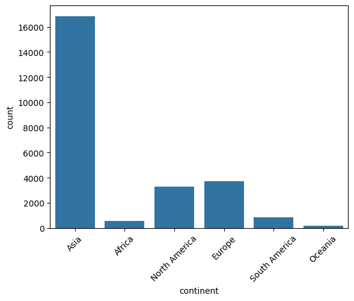

```python
sns.countplot(data=df, x='continent')
plt.xticks(rotation=45)
plt.show()
```

- The majority of employees are from Asia

#### Observations on education of employee

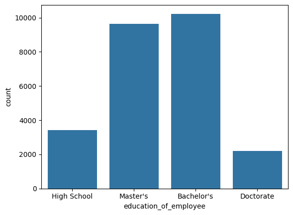

```python
sns.countplot(data=df, x='education_of_employee')
plt.show()
```

- Majority of employees have Master's and Bachelor's educations.

#### Observations on job experience

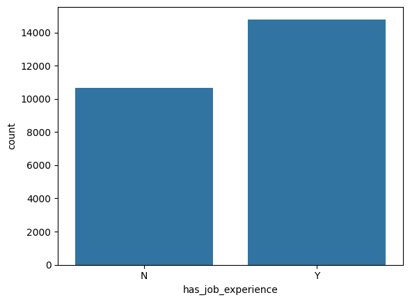

```python
sns.countplot(data=df, x='has_job_experience')
plt.show()
```

- There are more employees with job experience than those without job experience.

#### Observations on job training requirements

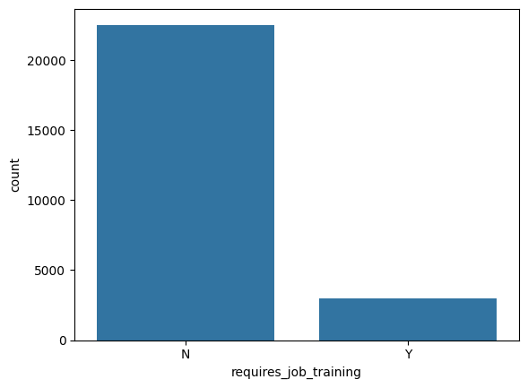

```python
sns.countplot(data=df, x='requires_job_training')
plt.show()
```

- There are much more employees that don't require job training than those that do require job training.

#### Observations on number of employees

```python
df['no_of_employees'].describe()
```

```
count     25480.000000
mean       5667.089207
std       22877.917453
min          11.000000
25%        1022.000000
50%        2109.000000
75%        3504.000000
max      602069.000000
Name: no_of_employees, dtype: float64
```

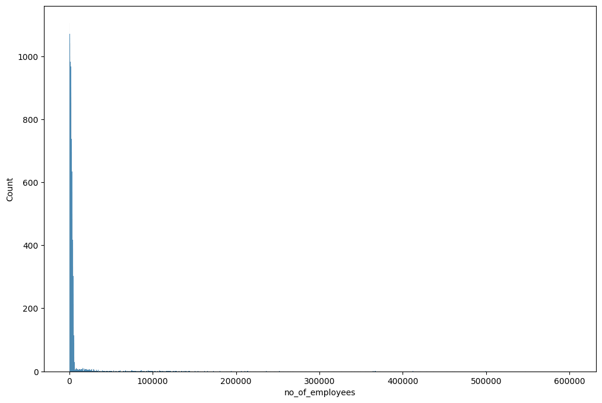

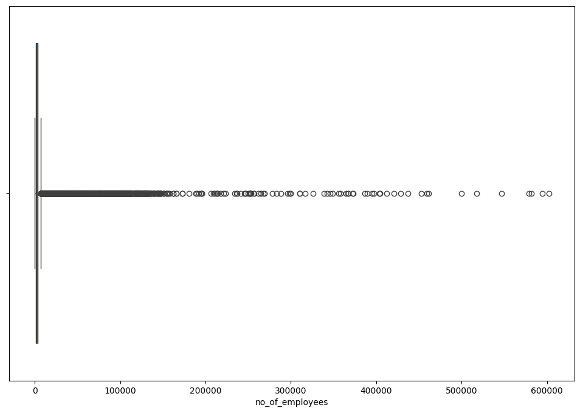

```python
plt.figure(figsize=(12, 8))
sns.histplot(data=df, x='no_of_employees')
plt.show()

plt.figure(figsize=(12, 8))
sns.boxplot(data=df, x='no_of_employees')
plt.show()
```

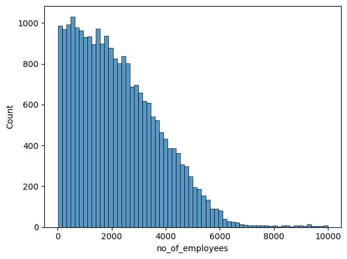

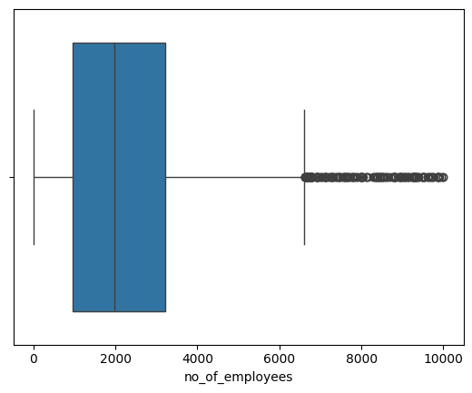

```python
# set limit on no_of_employees
sns.histplot(data=df[df['no_of_employees']<=10000], x='no_of_employees')
plt.show()

sns.boxplot(data=df[df['no_of_employees']<=10000], x='no_of_employees')
plt.show()
```

- The number of employees of the employer is mostly between 1000 and 3000 employees.
- There are many outliers in this distribution. The distribution is heavily right skewed.
- The max number of employees of the employer is 602069.

#### Observations on year of establishment

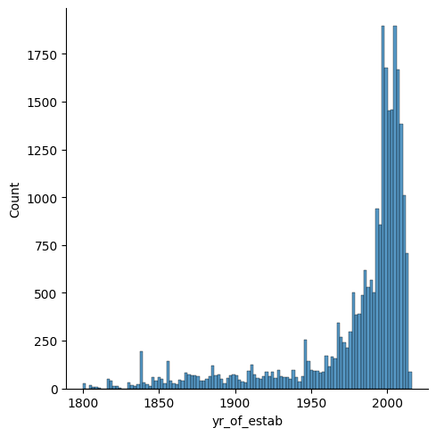

```python
sns.displot(data=df, x='yr_of_estab')
plt.show()
```

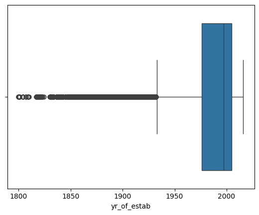

```python
sns.boxplot(data=df, x='yr_of_estab')
plt.show()
```

- The distribution of year of establishment of the employer is heavily left skewed.
- The median year of establishment is around 2000.
- There are a lot of outliers, with the min year of establishment being around 1800.

#### Observations on region of employment

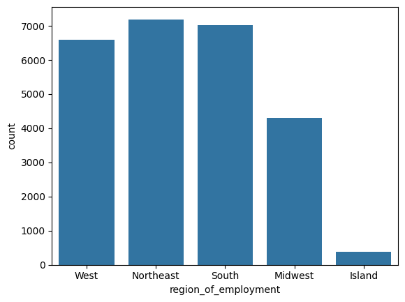

```python
sns.countplot(data=df, x='region_of_employment')
plt.show()
```

- The Northeast region of employment has the highest count, followed closely by South and then West.
- The count of the Island region is less than 500 and accounts for a small minority of the data.

#### Observations on prevailing wage

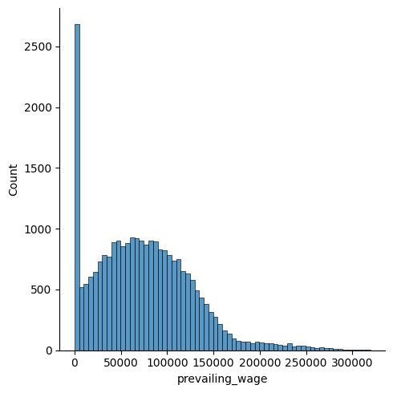

```python
sns.displot(data=df, x='prevailing_wage')
plt.show()
```

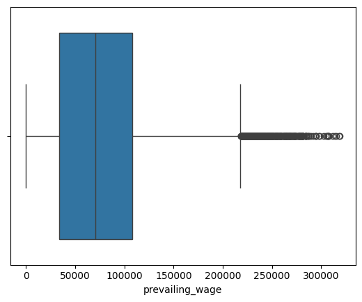

```python
sns.boxplot(data=df, x='prevailing_wage')
plt.show()
```

- The distribution of prevailing wage is right skewed.
- The median wage is around 70000.
- The distribution plot shows a high count of wage around 0.

#### Observations on unit of wage

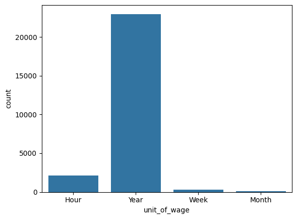

```python
sns.countplot(data=df, x='unit_of_wage')
plt.show()
```

- Most of the employees in this data have a yearly wage.
- There are very few employees with monthly or weekly wage.

#### Observations on full time position

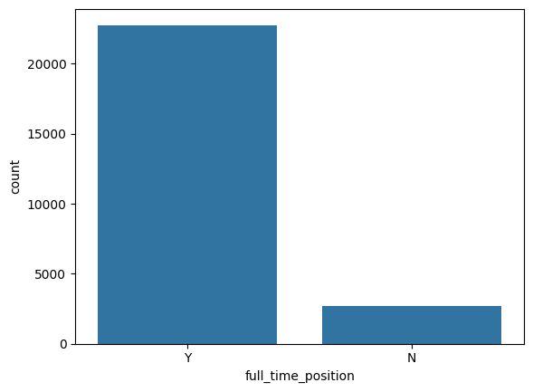

```python
sns.countplot(data=df, x='full_time_position')
plt.show()
```

- The large majority of employees in this data have full time positions.

#### Observations on case status

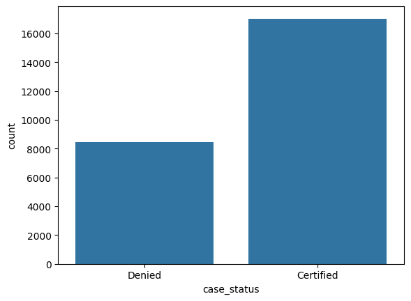

```python
sns.countplot(data=df, x='case_status')
plt.show()
```

- There are about twice as many certified visa applications than denied visa applications.

### Bivariate Analysis

**Leading Questions**:

1. Those with higher education may want to travel abroad for a well-paid job. Does education play a role in Visa certification?
2. How does the visa status vary across different continents?
3. Experienced professionals might look abroad for opportunities to improve their lifestyles and career development. Does work experience influence visa status?
4. In the United States, employees are paid at different intervals. Which pay unit is most likely to be certified for a visa?
5. The US government has established a prevailing wage to protect local talent and foreign workers. How does the visa status change with the prevailing wage?

#### Those with higher education may want to travel abroad for a well-paid job. Does education play a role in Visa certification?

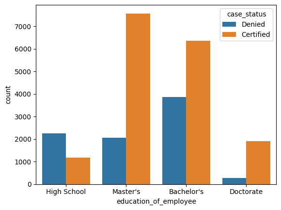

```python
sns.countplot(data=df, x='education_of_employee', hue='case_status')
plt.show()
```

```python
pd.crosstab(df['education_of_employee'], df['case_status'], normalize='index')
```

| case_status education_of_employee | Certified | Denied |
| --- | --- | --- |
| Bachelor's | 0.622142 | 0.377858 |
| Doctorate | 0.872263 | 0.127737 |
| High School | 0.340351 | 0.659649 |
| Master's | 0.786278 | 0.213722 |

- Higher levels of education have higher percentages of certified Visa status.
- High School education is the only level of education where there are more denied than certified Visa status.

#### How does the visa status vary across different continents?

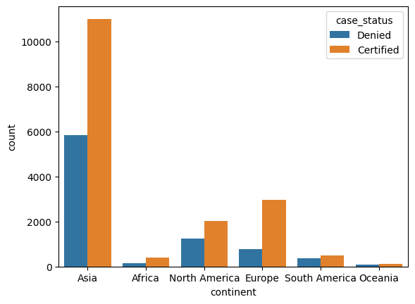

```python
sns.countplot(data=df, x='continent', hue='case_status')
plt.show()
```

```python
pd.crosstab(df['continent'], df['case_status'], normalize='index')
```

| case_status continent | Certified | Denied |
| --- | --- | --- |
| Africa | 0.720508 | 0.279492 |
| Asia | 0.653105 | 0.346895 |
| Europe | 0.792337 | 0.207663 |
| North America | 0.618773 | 0.381227 |
| Oceania | 0.635417 | 0.364583 |
| South America | 0.578638 | 0.421362 |

- Europe has the highest percentage of certified Visa status.
- South America has the lowest percentage of certified Visa status.

#### How does visa status vary between regions?

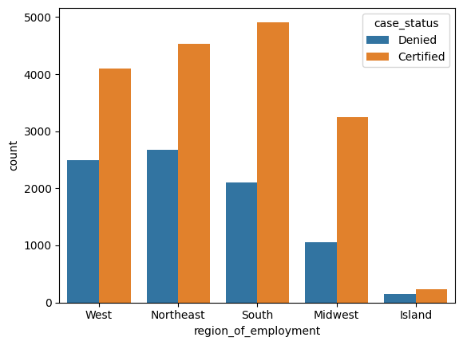

```python
sns.countplot(data=df, x='region_of_employment', hue='case_status')
plt.show()
```

```python
pd.crosstab(df['region_of_employment'], df['case_status'], normalize='index')
```

| case_status region_of_employment | Certified | Denied |
| --- | --- | --- |
| Island | 0.602667 | 0.397333 |
| Midwest | 0.755282 | 0.244718 |
| Northeast | 0.629048 | 0.370952 |
| South | 0.700157 | 0.299843 |
| West | 0.622533 | 0.377467 |

- Those employed in the midwest have the highest percentage of certified visa status.
- Those employed in an island region have the lowest percentage of certified visa status.

#### Experienced professionals might look abroad for opportunities to improve their lifestyles and career development. Does work experience influence visa status?

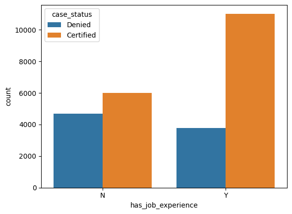

```python
sns.countplot(data=df, x='has_job_experience', hue='case_status')
plt.show()
```

```python
pd.crosstab(df['has_job_experience'], df['case_status'], normalize='index')
```

| case_status has_job_experience | Certified | Denied |
| --- | --- | --- |
| N | 0.561341 | 0.438659 |
| Y | 0.744764 | 0.255236 |

- People with job experience have a higher percentage of certified Visa status than people with no job experience.

#### How does visa status change with job training requirements?

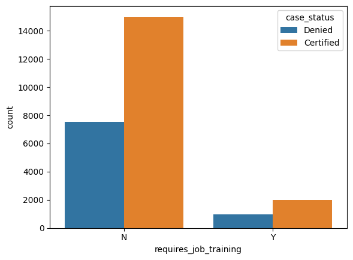

```python
sns.countplot(data=df, x='requires_job_training', hue='case_status')
plt.show()
```

```python
pd.crosstab(df['requires_job_training'], df['case_status'], normalize='index')
```

| case_status requires_job_training | Certified | Denied |
| --- | --- | --- |
| N | 0.666459 | 0.333541 |
| Y | 0.678849 | 0.321151 |

- There is no significant difference in percentage between certified and denied status in those that do and don't require job training.

#### Do full time positions have any affect on visa status?

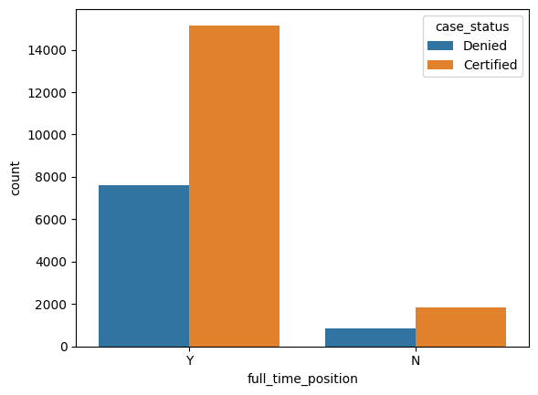

```python
sns.countplot(data=df, x='full_time_position', hue='case_status')
plt.show()
```

```python
pd.crosstab(df['full_time_position'], df['case_status'], normalize='index')
```

| case_status full_time_position | Certified | Denied |
| --- | --- | --- |
| N | 0.685260 | 0.314740 |
| Y | 0.665832 | 0.334168 |

- There is not much difference in certified vs denied visa status in full time positions and non-full time positions.

#### In the United States, employees are paid at different intervals. Which pay unit is most likely to be certified for a visa?

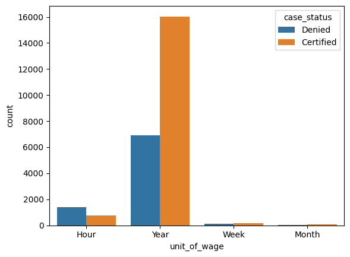

```python
sns.countplot(data=df, x='unit_of_wage', hue='case_status')
plt.show()
```

```python
pd.crosstab(df['unit_of_wage'], df['case_status'], normalize='index')
```

| case_status unit_of_wage | Certified | Denied |
| --- | --- | --- |
| Hour | 0.346314 | 0.653686 |
| Month | 0.617978 | 0.382022 |
| Week | 0.621324 | 0.378676 |
| Year | 0.698850 | 0.301150 |

- The Year wage unit has the highest percentage of certified Visa status.
- Hourly wage has the lowest percentage of certified Visa status.

#### The US government has established a prevailing wage to protect local talent and foreign workers. How does the visa status change with the prevailing wage?

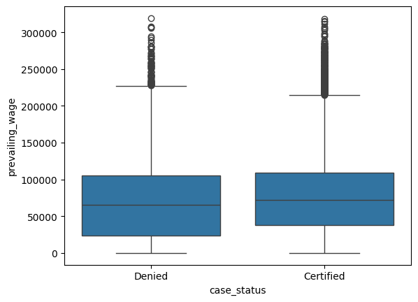

```python
sns.boxplot(data=df, x='case_status', y='prevailing_wage')
plt.show()
```

- The distributions of wage between denied and certified Visa status are fairly similar, however the median wage of certified Visa status is slightly higher.
- There are many outliers for both statuses.

#### How does visa status change with the size of the company?

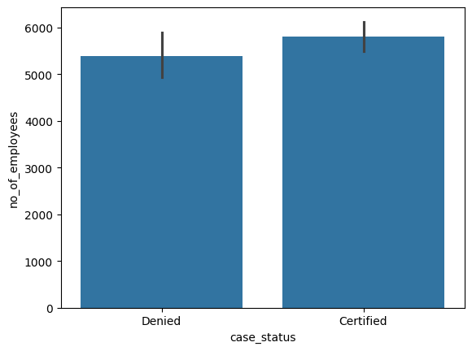

```python
sns.barplot(data=df, x='case_status', y='no_of_employees')
plt.show()
```

- The mean number of employees is slightly higher in certified visa statuses.

#### Does the company year of establishment have any affect on visa status?

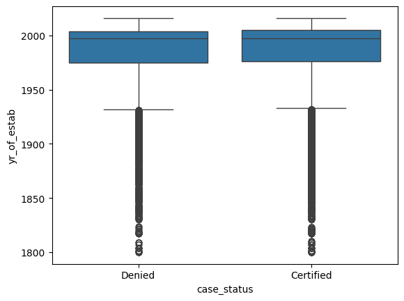

```python
sns.boxplot(data=df, x='case_status', y='yr_of_estab')
plt.show()
```

- Certified and denied visa status has similar distributions when it comes to year of establishment.

## Data Preprocessing

- Missing value treatment (if needed)
- Feature engineering
- Outlier detection and treatment (if needed)
- Preparing data for modeling
- Any other preprocessing steps (if needed)

```python
# replace values of case_status, Denied = 0 and Certified = 1
df['case_status'].replace({'Denied':0, 'Certified':1}, inplace=True)
```

```python
# define variables
X = df.drop(['case_status'], axis=1)
y = df['case_status']

X = pd.get_dummies(X, drop_first=True)
```

```python
# split data into training and test sets
X_train, X_test, y_train, y_test = train_test_split(X, y, test_size=0.3, random_state=1, stratify=y)
```

```python
X_train.head()
```

|  | no_of_employees | yr_of_estab | prevailing_wage | continent_Asia | continent_Europe | continent_North America | continent_Oceania | continent_South America | education_of_employee_Doctorate | education_of_employee_High School | education_of_employee_Master's | has_job_experience_Y | requires_job_training_Y | region_of_employment_Midwest | region_of_employment_Northeast | region_of_employment_South | region_of_employment_West | unit_of_wage_Month | unit_of_wage_Week | unit_of_wage_Year | full_time_position_Y |
| --- | --- | --- | --- | --- | --- | --- | --- | --- | --- | --- | --- | --- | --- | --- | --- | --- | --- | --- | --- | --- | --- |
| 21 | 1706 | 2013 | 137694.98 | False | False | True | False | False | False | False | True | True | False | True | False | False | False | False | False | True | False |
| 7332 | 2321 | 2009 | 11641.40 | False | True | False | False | False | True | False | False | False | False | False | False | False | True | False | False | True | True |
| 20579 | 1923 | 2005 | 21688.56 | False | False | True | False | False | False | False | False | False | False | False | True | False | False | False | False | True | True |
| 22326 | 434 | 1998 | 58341.54 | True | False | False | False | False | False | True | False | False | False | True | False | False | False | False | False | True | True |
| 13237 | 5870 | 2011 | 140996.50 | True | False | False | False | False | False | True | False | True | False | False | True | False | False | False | False | True | True |

```python
X_test.head()
```

|  | no_of_employees | yr_of_estab | prevailing_wage | continent_Asia | continent_Europe | continent_North America | continent_Oceania | continent_South America | education_of_employee_Doctorate | education_of_employee_High School | education_of_employee_Master's | has_job_experience_Y | requires_job_training_Y | region_of_employment_Midwest | region_of_employment_Northeast | region_of_employment_South | region_of_employment_West | unit_of_wage_Month | unit_of_wage_Week | unit_of_wage_Year | full_time_position_Y |
| --- | --- | --- | --- | --- | --- | --- | --- | --- | --- | --- | --- | --- | --- | --- | --- | --- | --- | --- | --- | --- | --- |
| 8165 | 3154 | 1965 | 40090.06 | False | False | True | False | False | True | False | False | True | False | True | False | False | False | False | False | True | True |
| 11219 | 4711 | 2007 | 47353.13 | False | True | False | False | False | False | False | False | True | False | False | False | False | True | False | False | True | True |
| 15810 | 1511 | 1998 | 61721.40 | False | False | True | False | False | False | False | True | True | False | False | True | False | False | False | False | True | True |
| 23680 | 2721 | 2002 | 95752.59 | True | False | False | False | False | False | False | True | False | False | False | False | False | True | False | False | True | True |
| 21194 | 1097 | 1855 | 37986.57 | False | False | True | False | False | False | False | True | True | False | False | False | True | False | False | False | True | False |

```python
# print number of rows for X train and test sets
print(X_train.shape[0], 'rows in training set.')
print(X_test.shape[0], 'rows in test set.')
```

```
17836 rows in training set.
7644 rows in test set.
```

```python
y_train.value_counts(normalize=True)
```

```
case_status
1    0.667919
0    0.332081
Name: proportion, dtype: float64
```

```python
y_test.value_counts(normalize=True)
```

```
case_status
1    0.667844
0    0.332156
Name: proportion, dtype: float64
```

## Model Building

### Model evaluation criterion

**Model can make wrong predictions such as:**

1. Model predicts visa application should get certified but actually should get denied.
2. Model predicts visa application should get denied but actually should get certified.

**Which case is more important?**

- Both cases are fairly equal in importance, so we will use F1 score to minimize both False Negatives and False Positives.

## Building bagging and boosting models

```python
# Create dictionary of training and test sets for use in functions
data_sets = {
    "X_train": X_train,
    "X_test": X_test,
    "y_train": y_train,
    "y_test": y_test,
}
```

```python
def get_metric_scores(model, data):
    """
    This function calculates and returns a Pandas DataFrame containing training and testing metric scores for a model.

    Args:
        model: The trained classification model.
        data: Dictionary containing keys 'X_train', 'X_test', 'y_train', 'y_test'.

    Returns:
        A Pandas DataFrame containing training and testing scores for accuracy, recall, precision, and F1-score.
    """

    # Extract data from dictionary
    X_train, X_test, y_train, y_test = data['X_train'], data['X_test'], data['y_train'], data['y_test']

    # Predict labels on training and testing sets
    pred_train = model.predict(X_train)
    pred_test = model.predict(X_test)

    # Calculate metrics directly in dictionary
    metrics = {
        'Accuracy': {
            'Train': accuracy_score(y_train, pred_train),
            'Test': accuracy_score(y_test, pred_test)
        },
        'Recall': {
            'Train': recall_score(y_train, pred_train),
            'Test': recall_score(y_test, pred_test)
        },
        'Precision': {
            'Train': precision_score(y_train, pred_train),
            'Test': precision_score(y_test, pred_test)
        },
        'F1': {
            'Train': f1_score(y_train, pred_train),
            'Test': f1_score(y_test, pred_test)
        }
    }

    # Create DataFrame from metrics dictionary
    df_metrics = pd.DataFrame.from_dict(metrics, orient='index')

    return df_metrics
```

```python
def get_confusion_matrix(model, data):
    """
    This function takes a trained model, data dictionary, and outputs confusion matrices for both training and testing sets.

    Args:
        model: The trained classification model
        data: Dictionary containing keys 'X_train', 'X_test', 'y_train', 'y_test'

    Returns:
        Confusion matrices visualizations
    """

    # Extract data from dictionary
    X_train, X_test, y_train, y_test = data['X_train'], data['X_test'], data['y_train'], data['y_test']

    # Train data confusion matrix
    train_predict = model.predict(X_train)
    cm_train = confusion_matrix(y_train, train_predict)

    # Create dataframe and format for heatmap (same as previous version)
    labels = np.asarray(
        [
            ["{0:0.0f}".format(item) + "\n{0:.2%}".format(item / cm_train.flatten().sum())]
            for item in cm_train.flatten()
        ]
    ).reshape(2, 2)

    plt.figure(figsize=(6, 4))
    sns.heatmap(cm_train, annot=labels, fmt="")
    plt.ylabel("True label")
    plt.xlabel("Predicted label")
    plt.title("Confusion Matrix - Training Set")

    # Test data confusion matrix
    test_predict = model.predict(X_test)
    cm_test = confusion_matrix(y_test, test_predict)

    # Create dataframe and format for heatmap (same as previous version)
    labels = np.asarray(
        [
            ["{0:0.0f}".format(item) + "\n{0:.2%}".format(item / cm_test.flatten().sum())]
            for item in cm_test.flatten()
        ]
    ).reshape(2, 2)

    plt.figure(figsize=(6, 4))
    sns.heatmap(cm_test, annot=labels, fmt="")
    plt.ylabel("True label")
    plt.xlabel("Predicted label")
    plt.title("Confusion Matrix - Test Set")
```

```python
# create empty lists for models used
models_untuned = []
models_tuned = []

# create empty lists for model names
model_names_untuned = []
model_names_tuned = []
```

### Decision Tree

```python
model_dt = DecisionTreeClassifier(random_state=1)
model_dt.fit(X_train, y_train)
```

```
DecisionTreeClassifier(random_state=1)
```

```python
models_untuned.append(model_dt)
model_names_untuned.append('Decision Tree')
```

```python
model_dt_scores = get_metric_scores(model_dt, data_sets)
model_dt_scores
```

|  | Train | Test |
| --- | --- | --- |
| Accuracy | 1.0 | 0.664835 |
| Recall | 1.0 | 0.742801 |
| Precision | 1.0 | 0.752232 |
| F1 | 1.0 | 0.747487 |

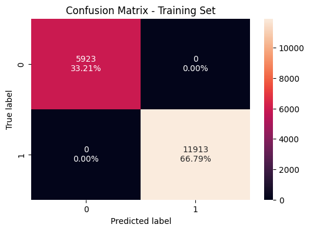

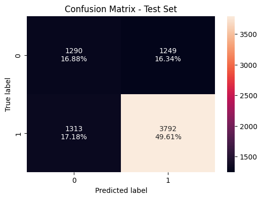

```python
get_confusion_matrix(model_dt, data_sets)
```

- There is a big discrepency between training and test scores, therefore the decision tree is overfitting the training data.

### Random Forest

```python
model_rf = RandomForestClassifier(random_state=1)
model_rf.fit(X_train, y_train)
```

```
RandomForestClassifier(random_state=1)
```

```python
models_untuned.append(model_rf)
model_names_untuned.append('Random Forest')
```

```python
get_metric_scores(model_rf, data_sets)
```

|  | Train | Test |
| --- | --- | --- |
| Accuracy | 0.999944 | 0.720827 |
| Recall | 0.999916 | 0.832125 |
| Precision | 1.000000 | 0.768869 |
| F1 | 0.999958 | 0.799247 |

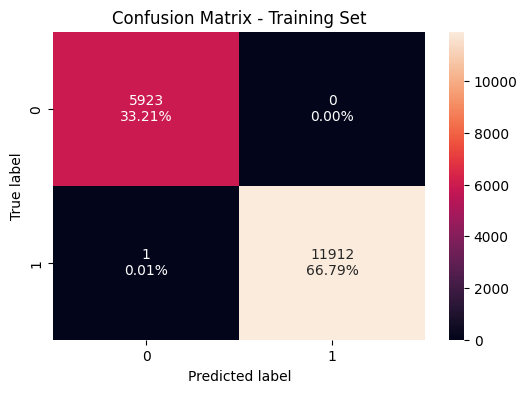

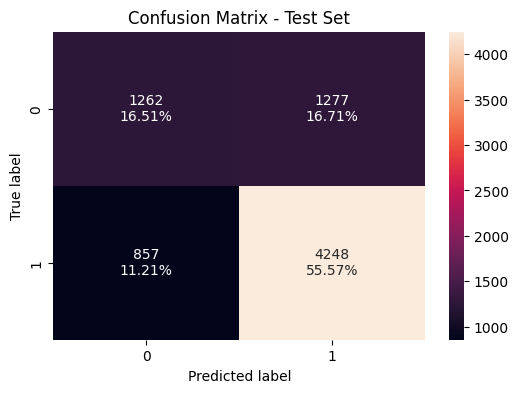

```python
get_confusion_matrix(model_rf, data_sets)
```

- There is a big discrepency between training and test scores, therefore the random forest is also overfitting the training data.

### Bagging

```python
model_bagging = BaggingClassifier(random_state=1)
model_bagging.fit(X_train, y_train)
```

```
BaggingClassifier(random_state=1)
```

```python
models_untuned.append(model_bagging)
model_names_untuned.append('Bagging')
```

```python
get_metric_scores(model_bagging, data_sets)
```

|  | Train | Test |
| --- | --- | --- |
| Accuracy | 0.985198 | 0.691523 |
| Recall | 0.985982 | 0.764153 |
| Precision | 0.991810 | 0.771711 |
| F1 | 0.988887 | 0.767913 |

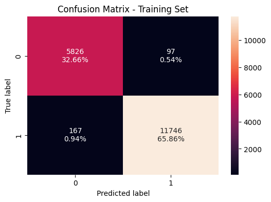

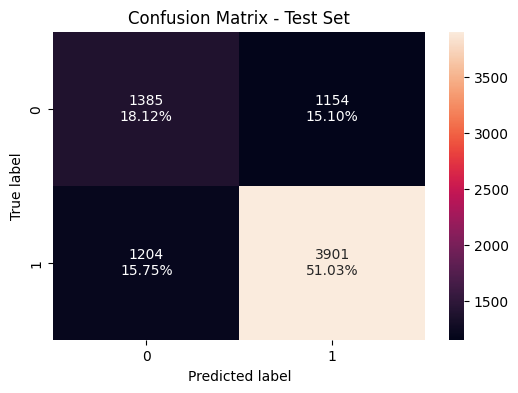

```python
get_confusion_matrix(model_bagging, data_sets)
```

- Again, there is a discrepency between training and test scores, thus the bagging model is also overfitting the training data.

### AdaBoost

```python
model_ab = AdaBoostClassifier(random_state=1)
model_ab.fit(X_train, y_train)
```

```
AdaBoostClassifier(random_state=1)
```

```python
models_untuned.append(model_ab)
model_names_untuned.append('AdaBoost')
```

```python
get_metric_scores(model_ab, data_sets)
```

|  | Train | Test |
| --- | --- | --- |
| Accuracy | 0.738226 | 0.734301 |
| Recall | 0.887182 | 0.885015 |
| Precision | 0.760688 | 0.757799 |
| F1 | 0.819080 | 0.816481 |

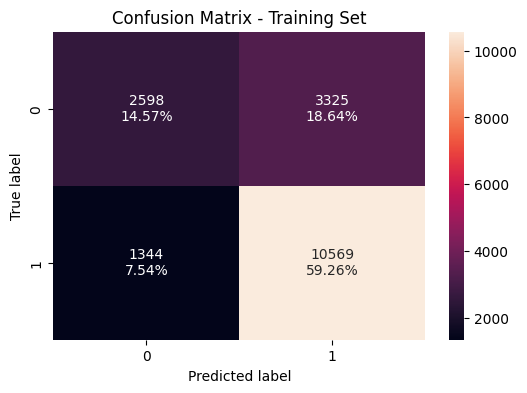

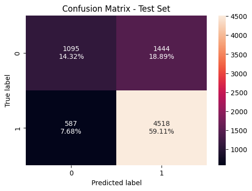

```python
get_confusion_matrix(model_ab, data_sets)
```

### Gradient Boost

```python
model_gb = GradientBoostingClassifier(random_state=1)
model_gb.fit(X_train, y_train)
```

```
GradientBoostingClassifier(random_state=1)
```

```python
models_untuned.append(model_gb)
model_names_untuned.append('Gradient Boosting')
```

```python
get_metric_scores(model_gb, data_sets)
```

|  | Train | Test |
| --- | --- | --- |
| Accuracy | 0.758802 | 0.744767 |
| Recall | 0.883740 | 0.876004 |
| Precision | 0.783042 | 0.772366 |
| F1 | 0.830349 | 0.820927 |

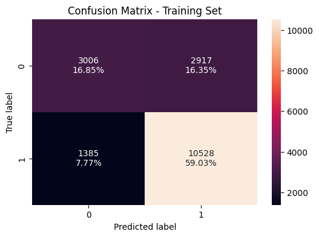

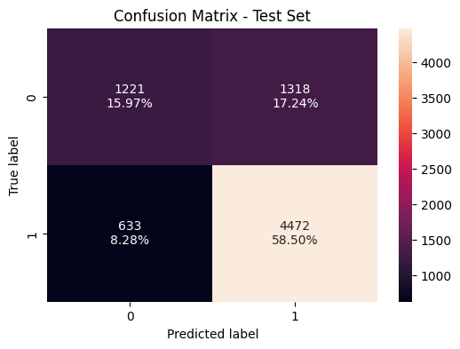

```python
get_confusion_matrix(model_gb, data_sets)
```

### XGBoost

```python
model_xgb = XGBClassifier(random_state=1,eval_metric='logloss')
model_xgb.fit(X_train, y_train)
```

```
XGBClassifier(base_score=None, booster=None, callbacks=None,
              colsample_bylevel=None, colsample_bynode=None,
              colsample_bytree=None, device=None, early_stopping_rounds=None,
              enable_categorical=False, eval_metric='logloss',
              feature_types=None, gamma=None, grow_policy=None,
              importance_type=None, interaction_constraints=None,
              learning_rate=None, max_bin=None, max_cat_threshold=None,
              max_cat_to_onehot=None, max_delta_step=None, max_depth=None,
              max_leaves=None, min_child_weight=None, missing=nan,
              monotone_constraints=None, multi_strategy=None, n_estimators=None,
              n_jobs=None, num_parallel_tree=None, random_state=1, ...)
```

```python
models_untuned.append(model_xgb)
model_names_untuned.append('XGBoost')
```

```python
get_metric_scores(model_xgb, data_sets)
```

|  | Train | Test |
| --- | --- | --- |
| Accuracy | 0.850807 | 0.729984 |
| Recall | 0.935952 | 0.851518 |
| Precision | 0.854537 | 0.768972 |
| F1 | 0.893394 | 0.808143 |

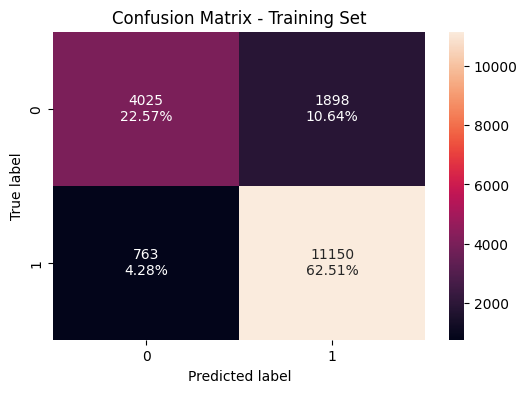

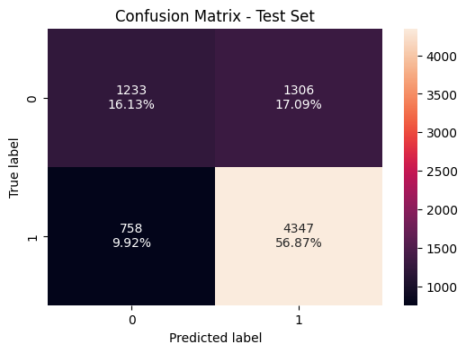

```python
get_confusion_matrix(model_xgb, data_sets)
```

### Comparing performance of untuned models

```python
def compare_model_scores(models_to_compare, data):
    """
    This function takes a tuple of models with their names and returns a dataframe comparing the scores of the models.

    Args:
        models_to_compare: Tuple of models and their respective names
        data: Dictionary containing keys 'X_train', 'X_test', 'y_train', 'y_test'

    Returns:
        Pandas DataFrame with models and their metric scores
    """

    # Extract testing data
    X_train, y_train, X_test, y_test = data['X_train'], data['y_train'], data['X_test'], data['y_test']

    # Initialize empty dictionary to store model scores
    model_scores = {}

    # Loop through each model and calculate metrics
    for model, model_name in models_to_compare:
        pred_train = model.predict(X_train)
        pred_test = model.predict(X_test)
        model_scores[model_name] = {
            'F1 Score (train)': f1_score(y_train, pred_train),
            'F1 Score (test)': f1_score(y_test, pred_test),
            'Acc. Score (train)': accuracy_score(y_train, pred_train),
            'Acc. Score (test)': accuracy_score(y_test, pred_test),
            'Prec. Score (train)': precision_score(y_train, pred_train),
            'Prec. Score (test)': precision_score(y_test, pred_test),
            'Rec. Score (train)': recall_score(y_train, pred_train),
            'Rec. Score (test)': recall_score(y_test, pred_test)
        }

    # Create DataFrame from model scores dictionary
    df_compare_models = pd.DataFrame.from_dict(model_scores, orient='index')

    return df_compare_models
```

```python
# join the the model list and model name list into a tuple to use in copmare_model_scores function
compare_untuned = tuple(zip(models_untuned, model_names_untuned))

compare_model_scores(compare_untuned, data_sets)
```

|  | F1 Score (train) | F1 Score (test) | Acc. Score (train) | Acc. Score (test) | Prec. Score (train) | Prec. Score (test) | Rec. Score (train) | Rec. Score (test) |
| --- | --- | --- | --- | --- | --- | --- | --- | --- |
| Decision Tree | 1.000000 | 0.747487 | 1.000000 | 0.664835 | 1.000000 | 0.752232 | 1.000000 | 0.742801 |
| Random Forest | 0.999958 | 0.799247 | 0.999944 | 0.720827 | 1.000000 | 0.768869 | 0.999916 | 0.832125 |
| Bagging | 0.988887 | 0.767913 | 0.985198 | 0.691523 | 0.991810 | 0.771711 | 0.985982 | 0.764153 |
| AdaBoost | 0.819080 | 0.816481 | 0.738226 | 0.734301 | 0.760688 | 0.757799 | 0.887182 | 0.885015 |
| Gradient Boosting | 0.830349 | 0.820927 | 0.758802 | 0.744767 | 0.783042 | 0.772366 | 0.883740 | 0.876004 |
| XGBoost | 0.893394 | 0.808143 | 0.850807 | 0.729984 | 0.854537 | 0.768972 | 0.935952 | 0.851518 |

- The untuned Gradient Boosting model had the highest F1 score out of the untuned models.

## Will tuning the hyperparameters improve the model performance?

**Note**

1. Sample parameter grids have been provided to do necessary hyperparameter tuning. These sample grids are expected to provide a balance between model performance improvement and execution time. One can extend/reduce the parameter grid based on execution time and system configuration.
- Please note that if the parameter grid is extended to improve the model performance further, the execution time will increase
- For Gradient Boosting:

```
param_grid = {
    "init": [AdaBoostClassifier(random_state=1),DecisionTreeClassifier(random_state=1)],
    "n_estimators": np.arange(50,110,25),
    "learning_rate": [0.01,0.1,0.05],
    "subsample":[0.7,0.9],
    "max_features":[0.5,0.7,1],
}
```

- For Adaboost:

```
param_grid = {
    "n_estimators": np.arange(50,110,25),
    "learning_rate": [0.01,0.1,0.05],
    "base_estimator": [
        DecisionTreeClassifier(max_depth=2, random_state=1),
        DecisionTreeClassifier(max_depth=3, random_state=1),
    ],
}
```

- For Bagging Classifier:

```
param_grid = {
    'max_samples': [0.8,0.9,1],
    'max_features': [0.7,0.8,0.9],
    'n_estimators' : [30,50,70],
}
```

- For Random Forest:

```
param_grid = {
    "n_estimators": [50,110,25],
    "min_samples_leaf": np.arange(1, 4),
    "max_features": [np.arange(0.3, 0.6, 0.1),'sqrt'],
    "max_samples": np.arange(0.4, 0.7, 0.1)
}
```

- For Decision Trees:

```
param_grid = {
    'max_depth': np.arange(2,6),
    'min_samples_leaf': [1, 4, 7],
    'max_leaf_nodes' : [10, 15],
    'min_impurity_decrease': [0.0001,0.001]
}
```

- For XGBoost:

```
param_grid={'n_estimators':np.arange(50,110,25),
            'scale_pos_weight':[1,2,5],
            'learning_rate':[0.01,0.1,0.05],
            'gamma':[1,3],
            'subsample':[0.7,0.9]
}
```

### Decision Tree Tuning

```python
# Type of classifier
model_dt_tuned = DecisionTreeClassifier(random_state=1)

# Grid of parameters to choose from
param_grid = {
    'max_depth': np.arange(2,6),
    'min_samples_leaf': [1, 4, 7],
    'max_leaf_nodes' : [10, 15],
    'min_impurity_decrease': [0.0001,0.001]
}

scorer = metrics.make_scorer(metrics.f1_score)

# Run the grid search
grid_obj = GridSearchCV(model_dt_tuned, param_grid, scoring=scorer)
grid_obj = grid_obj.fit(X_train, y_train)

# Set the clf to the best combination of parameters
model_dt_tuned = grid_obj.best_estimator_

# Fit the best algorithm to the data.
model_dt_tuned.fit(X_train, y_train)
```

```
DecisionTreeClassifier(max_depth=5, max_leaf_nodes=15,
                       min_impurity_decrease=0.0001, random_state=1)
```

```python
models_tuned.append(model_dt_tuned)
model_names_tuned.append('Decision Tree (tuned)')
```

```python
get_metric_scores(model_dt_tuned, data_sets)
```

|  | Train | Test |
| --- | --- | --- |
| Accuracy | 0.737834 | 0.728938 |
| Recall | 0.916226 | 0.914006 |
| Precision | 0.747961 | 0.740753 |
| F1 | 0.823587 | 0.818309 |

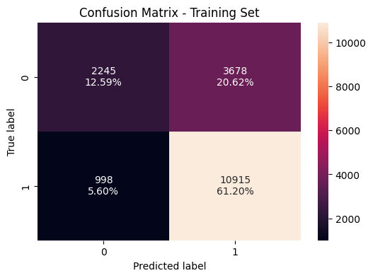

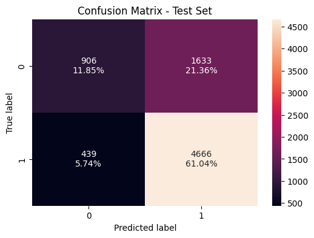

```python
get_confusion_matrix(model_dt_tuned, data_sets)
```

- The tuned decision tree model is no showing evidence of overfitting the training data.
- It has good performance providing an F1 score of 0.818.
- The tuned decision tree model improved greatly over the untuned decision tree model.

### Random Forest Tuning

```python
# Type of classifier
model_rf_tuned = RandomForestClassifier(random_state=1)

# Grid of parameters to choose from
param_grid = {
    "n_estimators": [50,110,25],
    "min_samples_leaf": np.arange(1, 4),
    "max_features": [np.arange(0.3, 0.6, 0.1),'sqrt'],
    "max_samples": np.arange(0.4, 0.7, 0.1)
}

scorer = metrics.make_scorer(metrics.f1_score)

# Run the grid search
grid_obj = GridSearchCV(model_rf_tuned, param_grid, scoring=scorer)
grid_obj = grid_obj.fit(X_train, y_train)

# Set the clf to the best combination of parameters
model_rf_tuned = grid_obj.best_estimator_

# Fit the best algorithm to the data.
model_rf_tuned.fit(X_train, y_train)
```

```
RandomForestClassifier(max_samples=0.4, min_samples_leaf=3, n_estimators=110,
                       random_state=1)
```

```python
models_tuned.append(model_rf_tuned)
model_names_tuned.append('Random Forest (tuned)')
```

```python
get_metric_scores(model_rf_tuned, data_sets)
```

|  | Train | Test |
| --- | --- | --- |
| Accuracy | 0.795582 | 0.743066 |
| Recall | 0.909091 | 0.873849 |
| Precision | 0.808631 | 0.771666 |
| F1 | 0.855923 | 0.819585 |

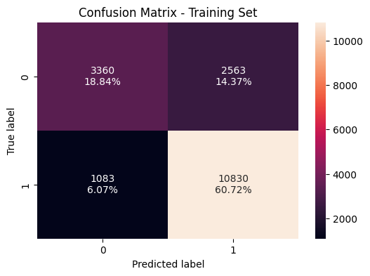

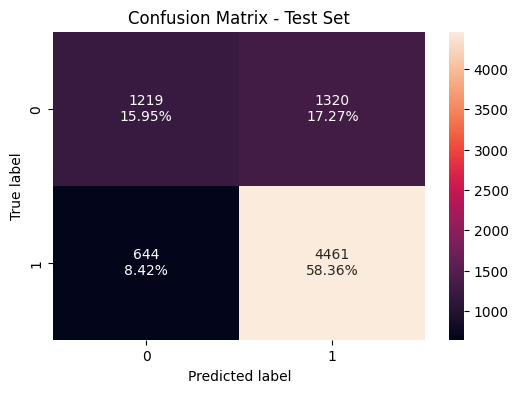

```python
get_confusion_matrix(model_rf_tuned, data_sets)
```

- There is a small discrepency between training and testing scores, providing evidence that the model is slightly overfitting training data.
- Both tuned and untuned random forest models showed evidence of overfitting training data.

### Bagging Tuning

```python
# Type of classifier
model_bagging_tuned = BaggingClassifier(random_state=1)

# Grid of parameters to choose from
param_grid = {
    'max_samples': [0.8,0.9,1],
    'max_features': [0.7,0.8,0.9],
    'n_estimators' : [30,50,70],
}

scorer = metrics.make_scorer(metrics.f1_score)

# Run the grid search
grid_obj = GridSearchCV(model_bagging_tuned, param_grid, scoring=scorer)
grid_obj = grid_obj.fit(X_train, y_train)

# Set the clf to the best combination of parameters
model_bagging_tuned = grid_obj.best_estimator_

# Fit the best algorithm to the data.
model_bagging_tuned.fit(X_train, y_train)
```

```
BaggingClassifier(max_features=0.7, max_samples=0.8, n_estimators=70,
                  random_state=1)
```

```python
models_tuned.append(model_bagging_tuned)
model_names_tuned.append('Bagging (tuned)')
```

```python
get_metric_scores(model_bagging_tuned, data_sets)
```

|  | Train | Test |
| --- | --- | --- |
| Accuracy | 0.998710 | 0.725929 |
| Recall | 0.999916 | 0.888737 |
| Precision | 0.998157 | 0.748186 |
| F1 | 0.999036 | 0.812427 |

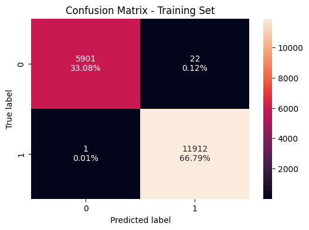

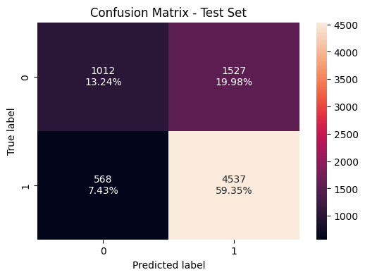

```python
get_confusion_matrix(model_bagging_tuned, data_sets)
```

- There is a large discrepency between training and testing data, providing evidence that this model is overfitting the training data.
- Both tuned and untuned bagging models are overfitting the training data, thus this would not be a good model to use.

### AdaBoost Tuning

```python
# Type of classifier
model_ab_tuned = AdaBoostClassifier(random_state=1)

# Grid of parameters to choose from
param_grid = {
    "n_estimators": np.arange(50,110,25),
    "learning_rate": [0.01,0.1,0.05],
    "estimator": [
        DecisionTreeClassifier(max_depth=2, random_state=1),
        DecisionTreeClassifier(max_depth=3, random_state=1)
    ]
}

scorer = metrics.make_scorer(metrics.f1_score)

# Run the grid search
grid_obj = GridSearchCV(model_ab_tuned, param_grid, scoring=scorer)
grid_obj = grid_obj.fit(X_train, y_train)

# Set the clf to the best combination of parameters
model_ab_tuned = grid_obj.best_estimator_

# Fit the best algorithm to the data.
model_ab_tuned.fit(X_train, y_train)
```

```
AdaBoostClassifier(estimator=DecisionTreeClassifier(max_depth=3,
                                                    random_state=1),
                   learning_rate=0.1, random_state=1)
```

```python
models_tuned.append(model_ab_tuned)
model_names_tuned.append('AdaBoost (tuned)')
```

```python
get_metric_scores(model_ab_tuned, data_sets)
```

|  | Train | Test |
| --- | --- | --- |
| Accuracy | 0.754317 | 0.740450 |
| Recall | 0.889365 | 0.881293 |
| Precision | 0.775679 | 0.765527 |
| F1 | 0.828641 | 0.819341 |

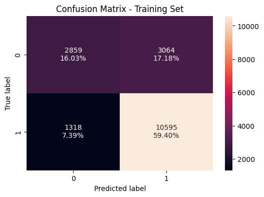

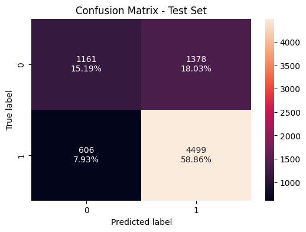

```python
get_confusion_matrix(model_ab_tuned, data_sets)
```

- The tuned version of the AdaBoost model slightly improved over the untuned version. F1 score increased from 0.816 to 0.819

### Gradient Boost Tuning

```python
# Type of classifier
model_gb_tuned = GradientBoostingClassifier(random_state=1)

# Grid of parameters to choose from
param_grid = {
    "init": [AdaBoostClassifier(random_state=1),DecisionTreeClassifier(random_state=1)],
    "n_estimators": np.arange(50,110,25),
    "learning_rate": [0.01,0.1,0.05],
    "subsample":[0.7,0.9],
    "max_features":[0.5,0.7,1],
}

scorer = metrics.make_scorer(metrics.f1_score)

# Run the grid search
grid_obj = GridSearchCV(model_gb_tuned, param_grid, scoring=scorer)
grid_obj = grid_obj.fit(X_train, y_train)

# Set the clf to the best combination of parameters
model_gb_tuned = grid_obj.best_estimator_

# Fit the best algorithm to the data.
model_gb_tuned.fit(X_train, y_train)
```

```
GradientBoostingClassifier(init=AdaBoostClassifier(random_state=1),
                           learning_rate=0.05, max_features=0.7, random_state=1,
                           subsample=0.9)
```

```python
models_tuned.append(model_gb_tuned)
model_names_tuned.append('Gradient Boosting (tuned)')
```

```python
get_metric_scores(model_gb_tuned, data_sets)
```

|  | Train | Test |
| --- | --- | --- |
| Accuracy | 0.753756 | 0.742936 |
| Recall | 0.883992 | 0.878355 |
| Precision | 0.777712 | 0.769389 |
| F1 | 0.827453 | 0.820269 |

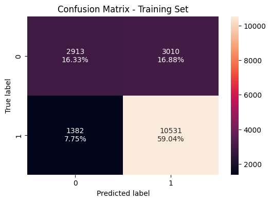

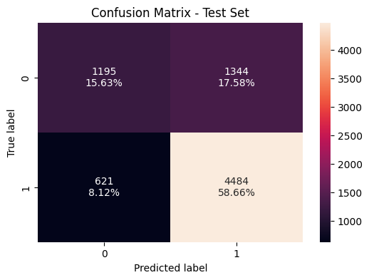

```python
get_confusion_matrix(model_gb_tuned, data_sets)
```

- The performance of the tuned gradient boosting model barely decreased from the untuned version.
- F1 score changed from 0.821 to 0.82

### XGBoost Tuning

```python
# Type of classifier
model_xgb_tuned = XGBClassifier(random_state=1)

# Grid of parameters to choose from
param_grid={'n_estimators':np.arange(50,110,25),
            'scale_pos_weight':[1,2,5],
            'learning_rate':[0.01,0.1,0.05],
            'gamma':[1,3],
            'subsample':[0.7,0.9]
}

scorer = metrics.make_scorer(metrics.f1_score)

# Run the grid search
grid_obj = GridSearchCV(model_xgb_tuned, param_grid, scoring=scorer)
grid_obj = grid_obj.fit(X_train, y_train)

# Set the clf to the best combination of parameters
model_xgb_tuned = grid_obj.best_estimator_

# Fit the best algorithm to the data.
model_xgb_tuned.fit(X_train, y_train)
```

```
XGBClassifier(base_score=None, booster=None, callbacks=None,
              colsample_bylevel=None, colsample_bynode=None,
              colsample_bytree=None, device=None, early_stopping_rounds=None,
              enable_categorical=False, eval_metric=None, feature_types=None,
              gamma=3, grow_policy=None, importance_type=None,
              interaction_constraints=None, learning_rate=0.05, max_bin=None,
              max_cat_threshold=None, max_cat_to_onehot=None,
              max_delta_step=None, max_depth=None, max_leaves=None,
              min_child_weight=None, missing=nan, monotone_constraints=None,
              multi_strategy=None, n_estimators=50, n_jobs=None,
              num_parallel_tree=None, random_state=1, ...)
```

```python
models_tuned.append(model_xgb_tuned)
model_names_tuned.append('XGBoost (tuned)')
```

```python
get_metric_scores(model_xgb_tuned, data_sets)
```

|  | Train | Test |
| --- | --- | --- |
| Accuracy | 0.761942 | 0.744244 |
| Recall | 0.891799 | 0.879726 |
| Precision | 0.782269 | 0.770062 |
| F1 | 0.833451 | 0.821249 |

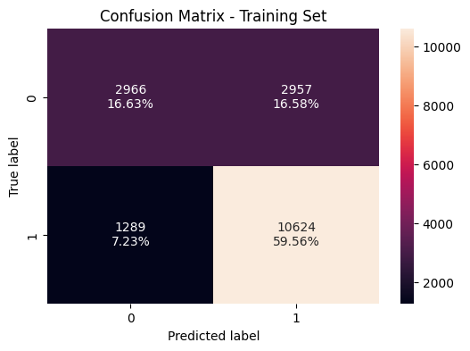

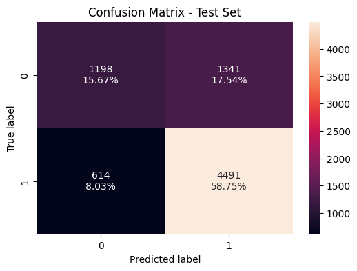

```python
get_confusion_matrix(model_xgb_tuned, data_sets)
```

- Performance slightly improved on the tuned version of the XGBoost model.
- F1 score increased from 0.808 to 0.821

### Comparing performance of tuned models

```python
compare_tuned = tuple(zip(models_tuned, model_names_tuned))
compare_model_scores(compare_tuned, data_sets)
```

|  | F1 Score (train) | F1 Score (test) | Acc. Score (train) | Acc. Score (test) | Prec. Score (train) | Prec. Score (test) | Rec. Score (train) | Rec. Score (test) |
| --- | --- | --- | --- | --- | --- | --- | --- | --- |
| Decision Tree (tuned) | 0.823587 | 0.818309 | 0.737834 | 0.728938 | 0.747961 | 0.740753 | 0.916226 | 0.914006 |
| Random Forest (tuned) | 0.855923 | 0.819585 | 0.795582 | 0.743066 | 0.808631 | 0.771666 | 0.909091 | 0.873849 |
| Bagging (tuned) | 0.999036 | 0.812427 | 0.998710 | 0.725929 | 0.998157 | 0.748186 | 0.999916 | 0.888737 |
| AdaBoost (tuned) | 0.828641 | 0.819341 | 0.754317 | 0.740450 | 0.775679 | 0.765527 | 0.889365 | 0.881293 |
| Gradient Boosting (tuned) | 0.827453 | 0.820269 | 0.753756 | 0.742936 | 0.777712 | 0.769389 | 0.883992 | 0.878355 |
| XGBoost (tuned) | 0.833451 | 0.821249 | 0.761942 | 0.744244 | 0.782269 | 0.770062 | 0.891799 | 0.879726 |

- The tuned XGBoost model had the highest F1 score out of the tuned models.

## Model Performance Comparison and Conclusions

```python
# join tuned and untuned model lists together
models_all = models_tuned + models_untuned
model_names_all = model_names_tuned + model_names_untuned

# create tuple of models and their names
compare_all = tuple(zip(models_all, model_names_all))

compare_model_scores(compare_all, data_sets)
```

|  | F1 Score (train) | F1 Score (test) | Acc. Score (train) | Acc. Score (test) | Prec. Score (train) | Prec. Score (test) | Rec. Score (train) | Rec. Score (test) |
| --- | --- | --- | --- | --- | --- | --- | --- | --- |
| Decision Tree (tuned) | 0.823587 | 0.818309 | 0.737834 | 0.728938 | 0.747961 | 0.740753 | 0.916226 | 0.914006 |
| Random Forest (tuned) | 0.855923 | 0.819585 | 0.795582 | 0.743066 | 0.808631 | 0.771666 | 0.909091 | 0.873849 |
| Bagging (tuned) | 0.999036 | 0.812427 | 0.998710 | 0.725929 | 0.998157 | 0.748186 | 0.999916 | 0.888737 |
| AdaBoost (tuned) | 0.828641 | 0.819341 | 0.754317 | 0.740450 | 0.775679 | 0.765527 | 0.889365 | 0.881293 |
| Gradient Boosting (tuned) | 0.827453 | 0.820269 | 0.753756 | 0.742936 | 0.777712 | 0.769389 | 0.883992 | 0.878355 |
| XGBoost (tuned) | 0.833451 | 0.821249 | 0.761942 | 0.744244 | 0.782269 | 0.770062 | 0.891799 | 0.879726 |
| Decision Tree | 1.000000 | 0.747487 | 1.000000 | 0.664835 | 1.000000 | 0.752232 | 1.000000 | 0.742801 |
| Random Forest | 0.999958 | 0.799247 | 0.999944 | 0.720827 | 1.000000 | 0.768869 | 0.999916 | 0.832125 |
| Bagging | 0.988887 | 0.767913 | 0.985198 | 0.691523 | 0.991810 | 0.771711 | 0.985982 | 0.764153 |
| AdaBoost | 0.819080 | 0.816481 | 0.738226 | 0.734301 | 0.760688 | 0.757799 | 0.887182 | 0.885015 |
| Gradient Boosting | 0.830349 | 0.820927 | 0.758802 | 0.744767 | 0.783042 | 0.772366 | 0.883740 | 0.876004 |
| XGBoost | 0.893394 | 0.808143 | 0.850807 | 0.729984 | 0.854537 | 0.768972 | 0.935952 | 0.851518 |

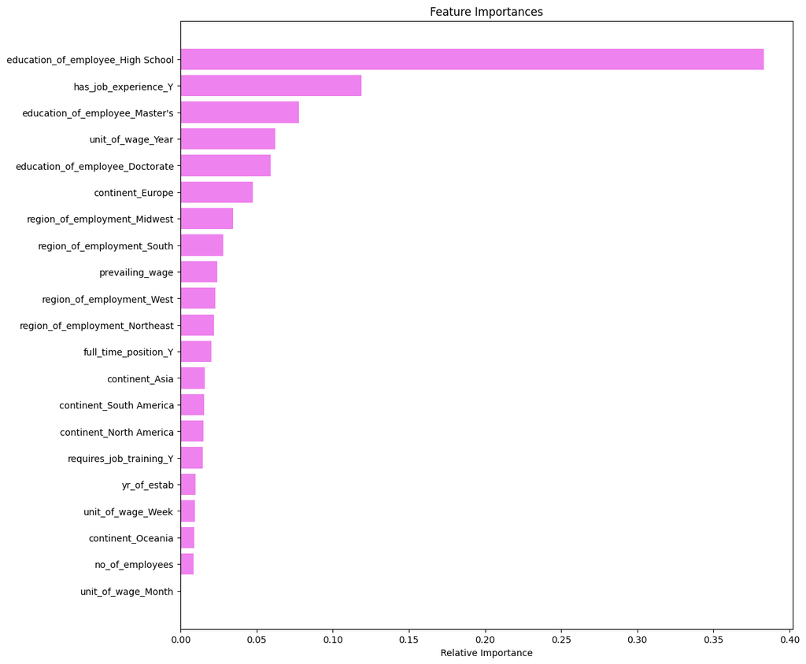

```python
importances = model_xgb_tuned.feature_importances_
indices = np.argsort(importances)
feature_names = list(X.columns)

plt.figure(figsize=(12,12))
plt.title('Feature Importances')
plt.barh(range(len(indices)), importances[indices], color='violet', align='center')
plt.yticks(range(len(indices)), [feature_names[i] for i in indices])
plt.xlabel('Relative Importance')
plt.show()
```

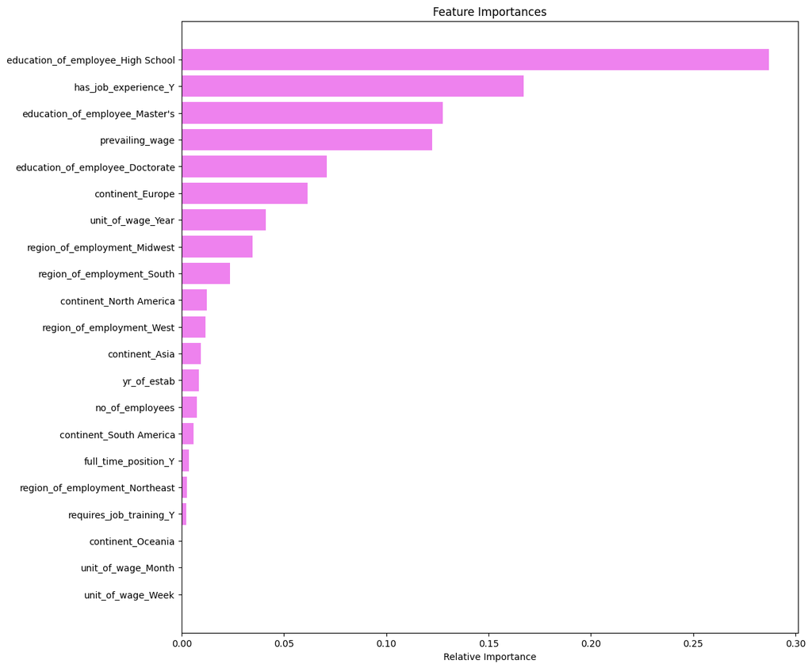

```python
importances = model_gb_tuned.feature_importances_
indices = np.argsort(importances)
feature_names = list(X.columns)

plt.figure(figsize=(12,12))
plt.title('Feature Importances')
plt.barh(range(len(indices)), importances[indices], color='violet', align='center')
plt.yticks(range(len(indices)), [feature_names[i] for i in indices])
plt.xlabel('Relative Importance')
plt.show()
```

- Both the tuned XGBoost and tuned Gradient Boosting models have the same top 3 importances, with education_of_employee_High School being the most outstanding factor in either of the models.

## Actionable Insights and Recommendations

- If the company decides that they would like to minimize both False Positives and False Negatives equally, the best model for them to use would be the tuned XGBoost model as it provided the best performance in terms of F1 score.
- If the company decided that they would like to minimzie False Positives, in the case that it would cost more resources to accept visas when they should be denied, the model that should be used is the untuned Gradient Boosting model.
- Education of employee - Those with a high school education are the highest indicator of being denied. Exploratory analysis also shows that the higher the education, the higher percentage of accepted visa applications.
- Job experience - Those with job experience have a much higher chance at being accepted and is a strong indicator for the model.
- Unit of wage - Out of the units, those on a yearly wage have a higher chance of being accepted and is also reflected in the relative importance of the XGBoost model.
- When the company is evaluating visa status, they should prioritize the education of the employee, their job experience, and their unit of wage as the deciding factors, as they have the biggest influence on status.